# Stroke prediction

AG

last update: 02 oktober 2022

## 0.1 Read data

In `smoking_status` Unknown should be changed to NA.

Also, it can be ordered: never < formerly < smokes

Other predictors seem to be OK

```r
df <- read_csv("data/healthcare-dataset-stroke-data.csv", col_types = "cfdfffffddcf", na = c("Unknown", "N/A"))
# if you set smoking_status to factor in col_types, na() won't work
df$smoking_status <- as_factor(df$smoking_status)
df$smoking_status <- fct_relevel(df$smoking_status, c("never smoked", "formerly smoked", "smokes"))
df$stroke <- factor(ifelse(df$stroke == 1, "yes", "no"), levels = c("no", "yes"))

df
```

| id | gender | age | hypertension | heart_disease | ever_married | work_type | Residence_type | avg_glucose_level | bmi | smoking_status | stroke |
| --- | --- | --- | --- | --- | --- | --- | --- | --- | --- | --- | --- |
| 9046 | Male | 67.00 | 0 | 1 | Yes | Private | Urban | 228.69 | 36.6 | formerly smoked | yes |
| 51676 | Female | 61.00 | 0 | 0 | Yes | Self-employed | Rural | 202.21 | NA | never smoked | yes |
| 31112 | Male | 80.00 | 0 | 1 | Yes | Private | Rural | 105.92 | 32.5 | never smoked | yes |
| 60182 | Female | 49.00 | 0 | 0 | Yes | Private | Urban | 171.23 | 34.4 | smokes | yes |
| 1665 | Female | 79.00 | 1 | 0 | Yes | Self-employed | Rural | 174.12 | 24.0 | never smoked | yes |
| 56669 | Male | 81.00 | 0 | 0 | Yes | Private | Urban | 186.21 | 29.0 | formerly smoked | yes |
| 53882 | Male | 74.00 | 1 | 1 | Yes | Private | Rural | 70.09 | 27.4 | never smoked | yes |
| 10434 | Female | 69.00 | 0 | 0 | No | Private | Urban | 94.39 | 22.8 | never smoked | yes |
| 27419 | Female | 59.00 | 0 | 0 | Yes | Private | Rural | 76.15 | NA | NA | yes |
| 60491 | Female | 78.00 | 0 | 0 | Yes | Private | Urban | 58.57 | 24.2 | NA | yes |

[output cut: 5100 more lines]

## 0.2 skimr description

Skip id column

```r
df$id <- NULL
skimr::skim_to_wide(df)
```

Data summary

| Name | Piped data |
| --- | --- |
| Number of rows | 5110 |
| Number of columns | 11 |
| _______________________ |  |
| Column type frequency: |  |
| factor | 8 |
| numeric | 3 |
| ________________________ |  |
| Group variables | None |

**Variable type: factor**

| skim_variable | n_missing | complete_rate | ordered | n_unique | top_counts |
| --- | --- | --- | --- | --- | --- |
| gender | 0 | 1.0 | FALSE | 3 | Fem: 2994, Mal: 2115, Oth: 1 |
| hypertension | 0 | 1.0 | FALSE | 2 | 0: 4612, 1: 498 |
| heart_disease | 0 | 1.0 | FALSE | 2 | 0: 4834, 1: 276 |
| ever_married | 0 | 1.0 | FALSE | 2 | Yes: 3353, No: 1757 |
| work_type | 0 | 1.0 | FALSE | 5 | Pri: 2925, Sel: 819, chi: 687, Gov: 657 |
| Residence_type | 0 | 1.0 | FALSE | 2 | Urb: 2596, Rur: 2514 |
| smoking_status | 1544 | 0.7 | FALSE | 3 | nev: 1892, for: 885, smo: 789 |
| stroke | 0 | 1.0 | FALSE | 2 | no: 4861, yes: 249 |

**Variable type: numeric**

| skim_variable | n_missing | complete_rate | mean | sd | p0 | p25 | p50 | p75 | p100 | hist |
| --- | --- | --- | --- | --- | --- | --- | --- | --- | --- | --- |
| age | 0 | 1.00 | 43.23 | 22.61 | 0.08 | 25.00 | 45.00 | 61.00 | 82.00 | ▅▆▇▇▆ |
| avg_glucose_level | 0 | 1.00 | 106.15 | 45.28 | 55.12 | 77.24 | 91.88 | 114.09 | 271.74 | ▇▃▁▁▁ |
| bmi | 201 | 0.96 | 28.89 | 7.85 | 10.30 | 23.50 | 28.10 | 33.10 | 97.60 | ▇▇▁▁▁ |

Target ‘stroke’ is imbalanced!

Smoking’s complete rate 0.7

#### 0.2.0.1 How many smoking_status in each target class?

```r
df %>% group_by(stroke, smoking_status) %>% summarise(N=n())
```

| stroke | smoking_status | N |
| --- | --- | --- |
| no | never smoked | 1802 |
| no | formerly smoked | 815 |
| no | smokes | 747 |
| no | NA | 1497 |
| yes | never smoked | 90 |
| yes | formerly smoked | 70 |
| yes | smokes | 42 |
| yes | NA | 47 |

BMI’s complete rate 0.96

#### 0.2.0.2 How many skipped BMI in each target class?

```r
df %>% filter(is.na(bmi)) %>% group_by(stroke) %>% summarise(N=n())
```

| stroke | N |
| --- | --- |
| no | 161 |
| yes | 40 |

One ‘Other’ gender to be removed

```r
df <- df %>% filter(gender != "Other")
```

## 0.3 EDA

### 0.3.1 Overview: a pairs plot

```r
GGally::ggpairs(df, aes(color = stroke, alpha = 0.2, dotsize = 0.02),
        upper = list(continuous = GGally::wrap("cor", size = 2.5)),
        diag = list(continuous = "barDiag")) +
  scale_color_brewer(palette = "Set1", direction = -1) +
  scale_fill_brewer(palette = "Set1", direction = -1)
```

[output not shown]

### 0.3.2 In details

#### 0.3.2.1 Stroke vs Age

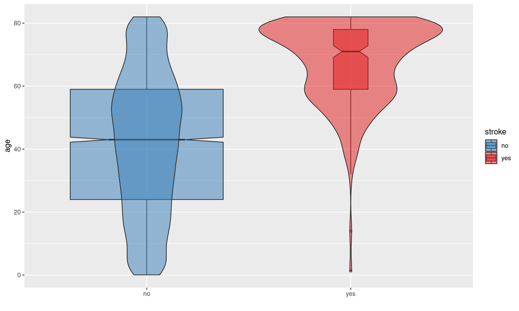

```r
ggplot(df, aes(stroke, age)) +
  geom_boxplot(aes(fill = stroke), alpha = 0.5, varwidth = T, notch = T) +
  geom_violin(aes(fill = stroke), alpha = 0.5) +
  scale_fill_brewer(palette = "Set1", direction = -1) +
  xlab("")
```

#### 0.3.2.2 Stroke vs Age + Gender

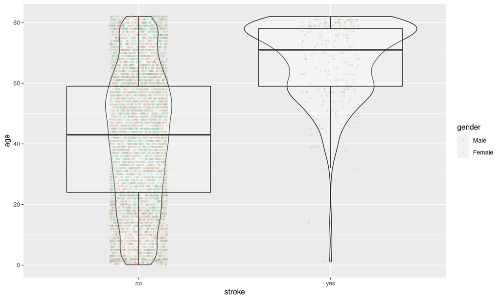

```r
ggplot(df, aes(stroke, age)) +
  geom_violin(alpha=0.3) +
  geom_jitter(alpha=0.2, size=0.8, width = 0.15, height = 0.1, aes(color = gender)) +
  geom_boxplot(alpha = 0.2) +
  scale_color_brewer(palette = "Set2", direction = -1)
```

On average, age is higher among stroke-yes group, there is no interaction between age and gender

#### 0.3.2.3 Stroke vs BMI

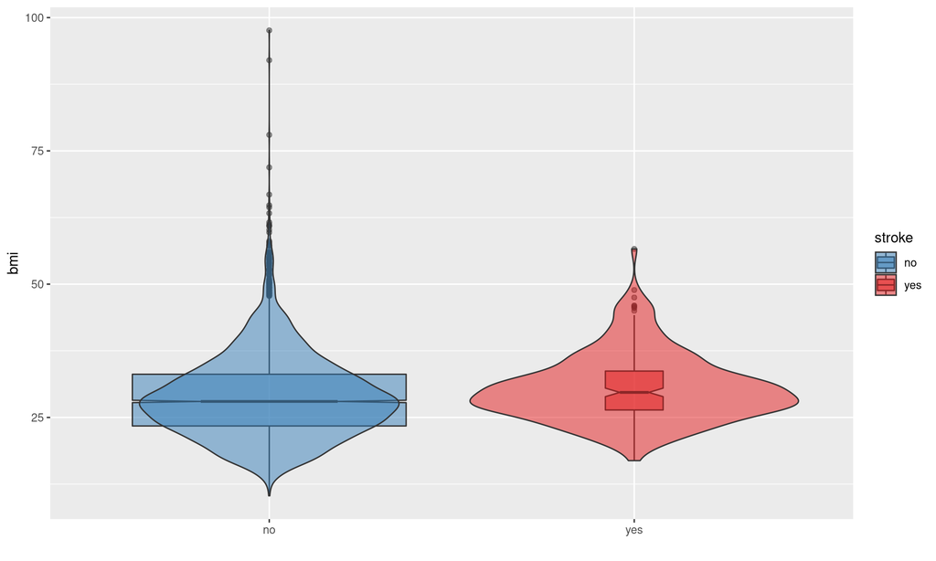

```r
ggplot(df, aes(stroke, bmi)) +
  geom_boxplot(aes(fill = stroke), alpha = 0.5, varwidth = T, notch = T) +
  geom_violin(aes(fill = stroke), alpha = 0.5) +
  scale_fill_brewer(palette = "Set1", direction = -1) +
  xlab("")
```

#### 0.3.2.4 Stroke vs Gender

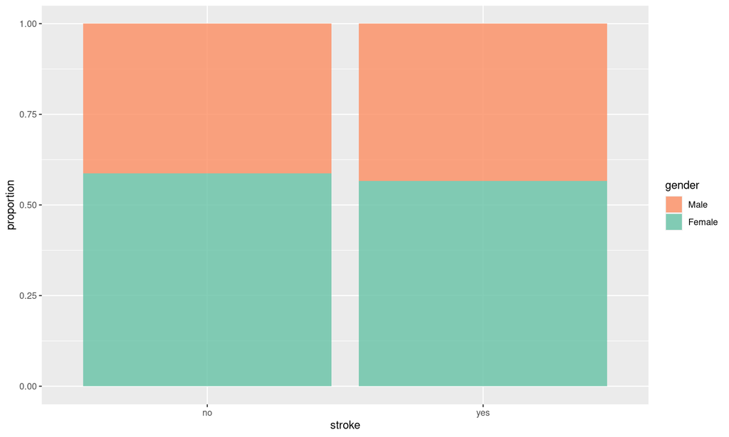

```r
gender <- df %>% group_by(stroke, gender) %>% summarize(N=n())

ggplot(gender, aes(stroke, N)) +
  geom_bar(aes(fill=gender), alpha = 0.8, stat = "identity", position = "fill")+
  scale_fill_brewer(palette = "Set2", direction = -1)+
  ylab("proportion")
```

Proportions in both stroke groups are roughly the same

#### 0.3.2.5 Stroke vs Hypertension

```r
hyptens <- df %>% group_by(stroke, hypertension) %>% summarize(N=n())

hyptens
```

| stroke | hypertension | N |
| --- | --- | --- |
| no | 0 | 4428 |
| no | 1 | 432 |
| yes | 0 | 183 |
| yes | 1 | 66 |

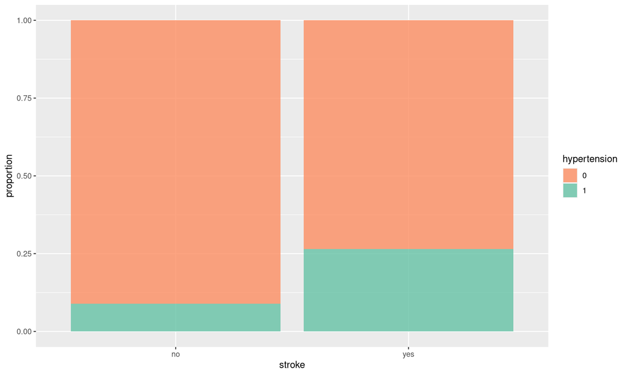

```r
ggplot(hyptens, aes(stroke, N)) +
  geom_bar(aes(fill=hypertension), alpha = 0.8, stat = "identity", position = "fill")+
  scale_fill_brewer(palette = "Set2", direction = -1)+
  ylab("proportion")
```

Hypertension occurred more often among stroke-yes

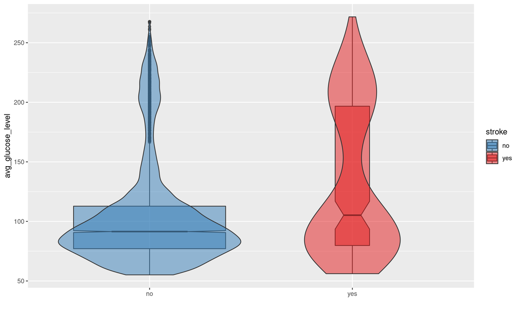

```r
ggplot(df, aes(stroke, avg_glucose_level)) +
  geom_boxplot(aes(fill = stroke), alpha = 0.5, varwidth = T, notch = T) +
  geom_violin(aes(fill = stroke), alpha = 0.5) +
  scale_fill_brewer(palette = "Set1", direction = -1) +
  xlab("")
```

## 0.4 Imputation

Using package mice

### 0.4.1 Run imputation

```r
library(mice)

imp_mice <- mice(df)
df_imp <- complete(imp_mice)
```

Number of NAs in BMI: 0

Number of NAs in Smoking 0

### 0.4.2 Check distributions

#### 0.4.2.1 BMI

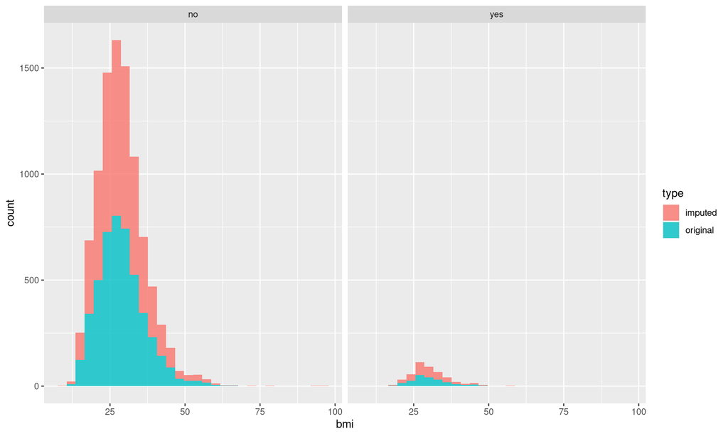

```r
bmi_imp_comp <- bind_rows(select(df, bmi, stroke) %>% mutate(type = rep("original", nrow(df))),
          select(df_imp, bmi, stroke) %>% mutate(type = rep("imputed", nrow(df_imp))))

ggplot(bmi_imp_comp, aes(bmi)) +
  geom_histogram(aes(fill=type), alpha=0.8) +
  facet_grid(cols = vars(stroke))
```

Means have not changed, which is good, I suppose.

#### 0.4.2.2 Smoking

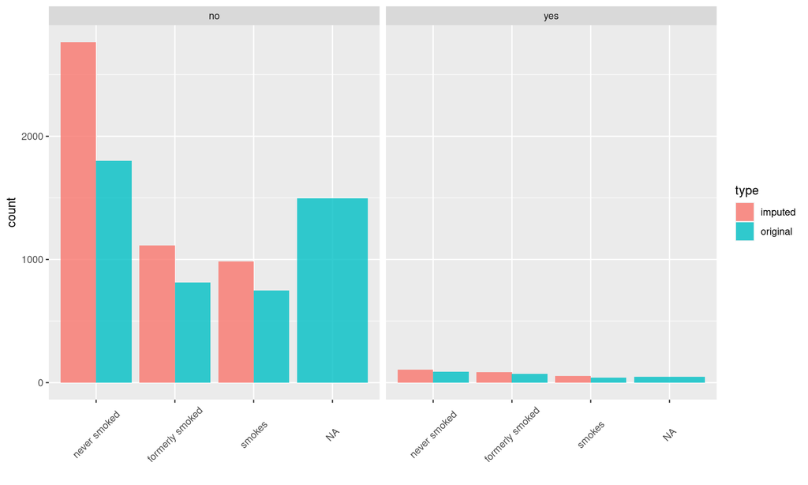

```r
smoke_imp_comp <- bind_rows(select(df, smoking_status, stroke) %>% mutate(type = rep("original", nrow(df))),
          select(df_imp, smoking_status, stroke) %>% mutate(type = rep("imputed", nrow(df_imp))))

ggplot(smoke_imp_comp, aes(smoking_status)) +
  geom_bar(aes(fill=type), alpha=0.8, position="dodge") +
  facet_grid(cols = vars(stroke)) +
  xlab("")+
  theme(axis.text.x = element_text(angle=45, vjust = 0.5))
```

Counts increased proportionally in all *Smoking* groups

## 0.5 Scaling & Normalization

Scale numeric features (including imputed BMI)

```r
# use caret::preProcess()
# preProcValues <- preProcess(training, method = c("center", "scale"))

df_scaled <- df_imp %>%
  select(avg_glucose_level, age, bmi) %>%
  scale() %>%
  data.frame()
```

## 0.6 Make Dummies

```r
# select vars
to_dum <- df_imp %>% select(gender, ever_married, work_type, Residence_type, smoking_status)
# make an obj
dummies <- dummyVars(~ ., data=to_dum)
# apply it
df_dummy <- data.frame(predict(dummies, newdata=to_dum))

head(df_dummy)
```

|  | gender.Male | gender.Female | gender.Other | ever_married.Yes | ever_married.No | work_type.Private | work_type.Self.employed | work_type.Govt_job | work_type.children | work_type.Never_worked | Residence_type.Urban | Residence_type.Rural | smoking_status.never.smoked | smoking_status.formerly.smoked | smoking_status.smokes |
| --- | --- | --- | --- | --- | --- | --- | --- | --- | --- | --- | --- | --- | --- | --- | --- |
| 1 | 1 | 0 | 0 | 1 | 0 | 1 | 0 | 0 | 0 | 0 | 1 | 0 | 0 | 1 | 0 |
| 2 | 0 | 1 | 0 | 1 | 0 | 0 | 1 | 0 | 0 | 0 | 0 | 1 | 1 | 0 | 0 |
| 3 | 1 | 0 | 0 | 1 | 0 | 1 | 0 | 0 | 0 | 0 | 0 | 1 | 1 | 0 | 0 |
| 4 | 0 | 1 | 0 | 1 | 0 | 1 | 0 | 0 | 0 | 0 | 1 | 0 | 0 | 0 | 1 |
| 5 | 0 | 1 | 0 | 1 | 0 | 0 | 1 | 0 | 0 | 0 | 0 | 1 | 1 | 0 | 0 |
| 6 | 1 | 0 | 0 | 1 | 0 | 1 | 0 | 0 | 0 | 0 | 1 | 0 | 0 | 1 | 0 |

## 0.7 Join scaled and dummies and the rest

```r
df_proc <- bind_cols(df_scaled, df_dummy, select(df, hypertension, heart_disease, stroke))
head(df_proc)
```

|  | avg_glucose_level | age | bmi | gender.Male | gender.Female | gender.Other | ever_married.Yes | ever_married.No | work_type.Private | work_type.Self.employed | work_type.Govt_job | work_type.children | work_type.Never_worked | Residence_type.Urban | Residence_type.Rural | smoking_status.never.smoked | smoking_status.formerly.smoked | smoking_status.smokes | hypertension | heart_disease | stroke |
| --- | --- | --- | --- | --- | --- | --- | --- | --- | --- | --- | --- | --- | --- | --- | --- | --- | --- | --- | --- | --- | --- |
| 1 | 2.706185068 | 1.0511391 | 0.977287023 | 1 | 0 | 0 | 1 | 0 | 1 | 0 | 0 | 0 | 0 | 1 | 0 | 0 | 1 | 0 | 0 | 1 | yes |
| 2 | 2.121444031 | 0.7858118 | 0.033250262 | 0 | 1 | 0 | 1 | 0 | 0 | 1 | 0 | 0 | 0 | 0 | 1 | 1 | 0 | 0 | 0 | 0 | yes |
| 3 | -0.004866938 | 1.6260150 | 0.454239628 | 1 | 0 | 0 | 1 | 0 | 1 | 0 | 0 | 0 | 0 | 0 | 1 | 1 | 0 | 0 | 0 | 1 | yes |
| 4 | 1.437332349 | 0.2551571 | 0.696627445 | 0 | 1 | 0 | 1 | 0 | 1 | 0 | 0 | 0 | 0 | 1 | 0 | 0 | 0 | 1 | 0 | 0 | yes |
| 5 | 1.501150385 | 1.5817938 | -0.630126921 | 0 | 1 | 0 | 1 | 0 | 0 | 1 | 0 | 0 | 0 | 0 | 1 | 1 | 0 | 0 | 1 | 0 | yes |
| 6 | 1.768126184 | 1.6702363 | 0.007735755 | 1 | 0 | 0 | 1 | 0 | 1 | 0 | 0 | 0 | 0 | 1 | 0 | 0 | 1 | 0 | 0 | 0 | yes |

# 1 Modelling

## 1.1 Params tuning

ROC-optimization is better when data is imbalanced

Kappa-optimization is also good

```r
# for ROC
fit_ctrl_roc <- trainControl(## 5-fold CV
                           method = "repeatedcv",
                           number = 5,
                           repeats = 10,
                           allowParallel = T,
                           classProbs = T,
                           summaryFunction = twoClassSummary)
# for kappa
fit_ctrl_kp <- trainControl(## 5-fold CV
                           method = "repeatedcv",
                           number = 5,
                           repeats = 10,
                           allowParallel = T)

fit_ctrl_kp10 <- trainControl(## 10-fold CV
                           method = "repeatedcv",
                           number = 10,
                           repeats = 10,
                           allowParallel = T)
```

## 1.2 Split data

Imbalanced data - use SMOTE to create training data set, but not testing data set

```r
set.seed(1234)
sample_set <- createDataPartition(y = df_proc$stroke, p = .75, list = FALSE)
df_train <- df_proc[sample_set,]
df_test <- df_proc[-sample_set,]

# DMwR::SMOTE for imbalanced data: over=225 and under=150 give me 1:1 ratio
df_train_smote <- SMOTE(stroke ~ ., data.frame(df_train), perc.over = 1725, perc.under = 106)

df_train_smote %>% group_by(stroke) %>% summarise(N=n())
```

| stroke | N |
| --- | --- |
| no | 3369 |
| yes | 3366 |

# 2 Random Forest

## 2.1 Training and validation

### 2.1.1 Kappa-optimized

For imbalanced classes

```r
library(doParallel)

cl <- makePSOCKcluster(THREADS)
registerDoParallel(cl)

set.seed(123)

fit_rf <- train(stroke ~ .,
                 data = df_train_smote,
                 metric = "Kappa",
                 method = "rf",
                 trControl = fit_ctrl_kp,
                 tuneGrid = expand.grid(.mtry = seq(2, 6, 0.5)), # I've tried all values greater than these
                 verbosity = 0,
                 verbose = FALSE)
stopCluster(cl)

fit_rf
```

```
## Random Forest
##
## 6735 samples
##   20 predictor
##    2 classes: 'no', 'yes'
##
## No pre-processing
## Resampling: Cross-Validated (5 fold, repeated 10 times)
## Summary of sample sizes: 5388, 5388, 5387, 5389, 5388, 5389, ...
## Resampling results across tuning parameters:
##
##   mtry  Accuracy   Kappa
##   2.0   0.9630585  0.9261154
##   2.5   0.9627021  0.9254026
##   3.0   0.9663099  0.9326183
##   3.5   0.9687895  0.9375775
##   4.0   0.9684925  0.9369834
##   4.5   0.9686855  0.9373695
##   5.0   0.9691161  0.9382308
##   5.5   0.9690865  0.9381716
##   6.0   0.9690420  0.9380826
##
## Kappa was used to select the optimal model using the largest value.
## The final value used for the model was mtry = 5.
```

### 2.1.2 ROC-optimized

```r
cl <- makePSOCKcluster(THREADS)
registerDoParallel(cl)

set.seed(120)

fit_rf_roc <- train(stroke ~ .,
                 data = df_train_smote,
                 metric = "ROC",
                 method = "rf",
                 trControl = fit_ctrl_roc,
                 tuneGrid = expand.grid(.mtry = seq(2, 6, 0.5)),
                 verbosity = 0,
                 verbose = FALSE)
stopCluster(cl)

fit_rf_roc
```

```
## Random Forest
##
## 6735 samples
##   20 predictor
##    2 classes: 'no', 'yes'
##
## No pre-processing
## Resampling: Cross-Validated (5 fold, repeated 10 times)
## Summary of sample sizes: 5389, 5387, 5388, 5388, 5388, 5388, ...
## Resampling results across tuning parameters:
##
##   mtry  ROC        Sens       Spec
##   2.0   0.9892145  0.9856338  0.9405227
##   2.5   0.9892290  0.9851886  0.9404929
##   3.0   0.9913162  0.9899080  0.9422163
##   3.5   0.9923429  0.9925198  0.9435529
##   4.0   0.9922855  0.9928168  0.9435828
##   4.5   0.9922846  0.9926386  0.9435529
##   5.0   0.9927969  0.9924602  0.9451573
##   5.5   0.9930375  0.9914215  0.9461675
##   6.0   0.9930317  0.9915700  0.9462864
##
## ROC was used to select the optimal model using the largest value.
## The final value used for the model was mtry = 5.5.
```

## 2.2 Features importance

### 2.2.1 Kappa-optimized model

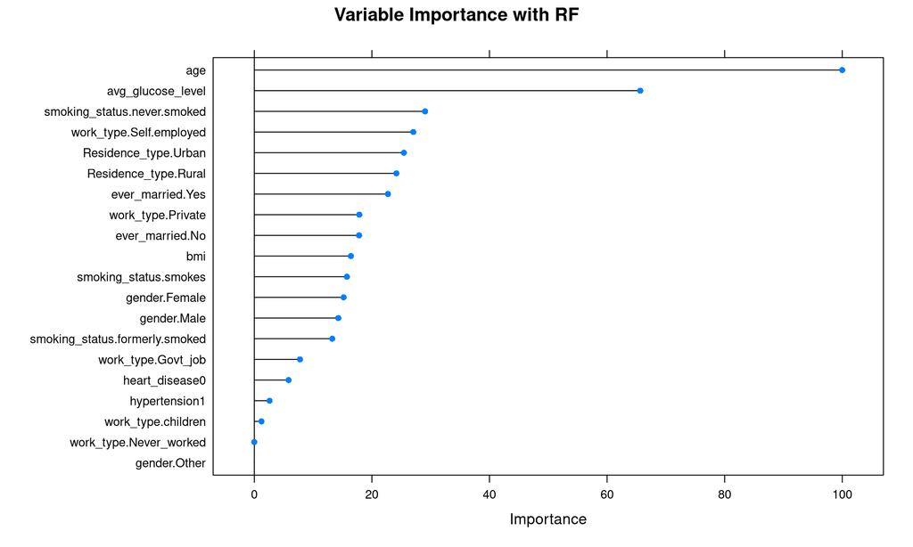

```r
imp_vars_rf <- varImp(fit_rf)

plot(imp_vars_rf, main = "Variable Importance with RF")
```

### 2.2.2 ROC-optimized model

it’s the same

## 2.3 Testing

### 2.3.1 ROC & AUC

a function for roc-stuff

```r
get_roc <- function(fit.obj, testing.df){
  pred_prob <- predict.train(fit.obj, newdata = testing.df, type = "prob")
  pred_roc <- prediction(predictions = pred_prob$yes, labels = testing.df$stroke)
  perf_roc <- performance(pred_roc, measure = "tpr", x.measure = "fpr")
  return(list(perf_roc, pred_roc))
}
```

#### 2.3.1.1 ROC-curve for kappa-optimized model

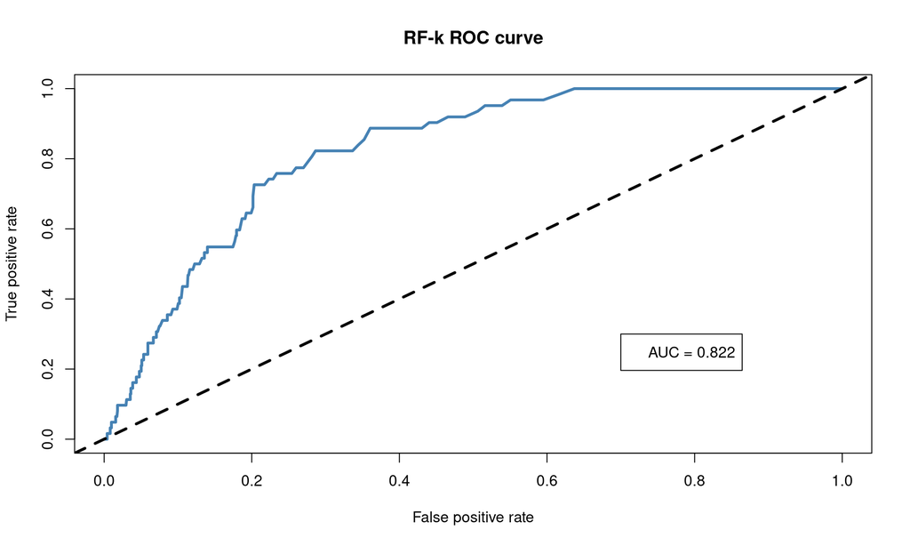

```r
# calculate ROC
perf_pred <- get_roc(fit_rf, df_test)
perf_rf <- perf_pred[[1]]
pred_rf <- perf_pred[[2]]

# take AUC
auc_rf <- round(unlist(slot(performance(pred_rf, measure = "auc"), "y.values")), 3)

# plot
plot(perf_rf, main = "RF-k ROC curve", col = "steelblue", lwd = 3)
abline(a = 0, b = 1, lwd = 3, lty = 2, col = 1)
legend(x = 0.7, y = 0.3, legend = paste0("AUC = ", auc_rf))
```

#### 2.3.1.2 ROC-curve for ROC-optimized model

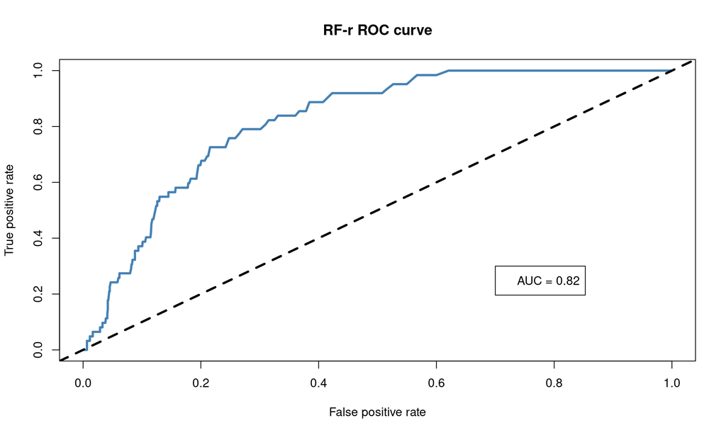

```r
# calculate ROC
perf_pred_roc <- get_roc(fit_rf_roc, df_test)
perf_rf_roc <- perf_pred_roc[[1]]
pred_rf_roc <- perf_pred_roc[[2]]

# take AUC
auc_rf_roc <- round(unlist(slot(performance(pred_rf_roc, measure = "auc"), "y.values")), 3)

# plot
plot(perf_rf_roc, main = "RF-r ROC curve", col = "steelblue", lwd = 3)
abline(a = 0, b = 1, lwd = 3, lty = 2, col = 1)
legend(x = 0.7, y = 0.3, legend = paste0("AUC = ", auc_rf_roc))
```

So, we can adjust TPR/FPR cutoff to predict all strokes

### 2.3.2 TPR, FPR vs Probability cutoff

At which probability cut-off, you’ll get TPR = 1.0?

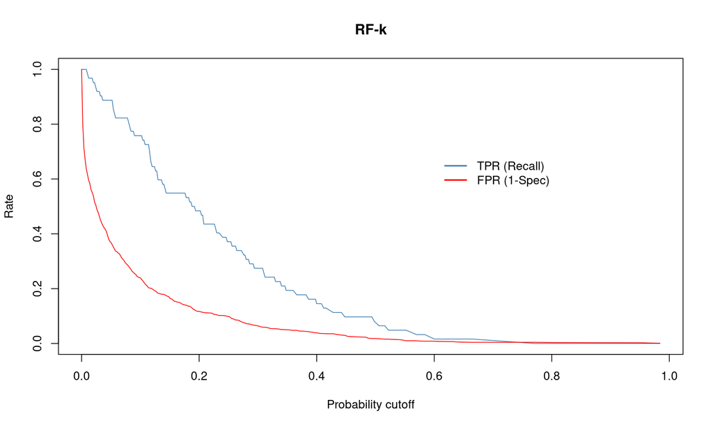

```r
# use pred_rf (pred_roc) object
plot(performance(pred_rf, measure = "tpr", x.measure = "cutoff"),
     col="steelblue",
     ylab = "Rate",
     xlab="Probability cutoff")

plot(performance(pred_rf, measure = "fpr", x.measure = "cutoff"),
     add = T, col = "red")

legend(x = 0.6,y = 0.7, c("TPR (Recall)", "FPR (1-Spec)"),
       lty = 1, col =c('steelblue', 'red'), bty = 'n', cex = 1, lwd = 2)

#abline(v = 0.02, lwd = 2, lty=6)

title("RF-k")
```

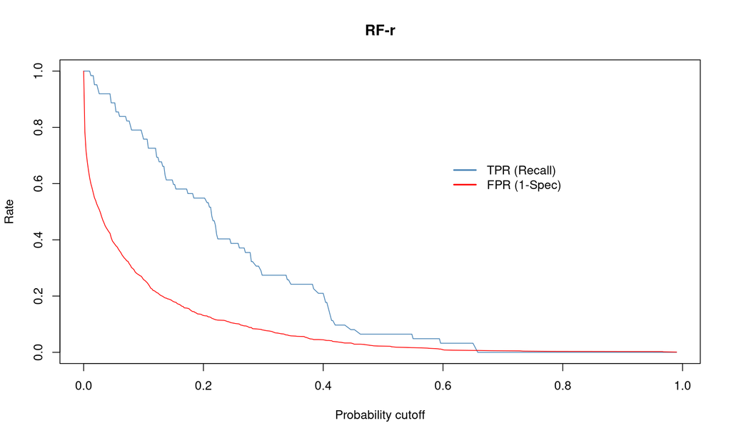

```r
# use pred_rf (pred_roc) object
plot(performance(pred_rf_roc, measure = "tpr", x.measure = "cutoff"),
     col = "steelblue",
     ylab = "Rate",
     xlab = "Probability cutoff")

plot(performance(pred_rf_roc, measure = "fpr", x.measure = "cutoff"),
     add = T, col = "red")

legend(x = 0.6,y = 0.7, c("TPR (Recall)", "FPR (1-Spec)"),
       lty = 1, col = c('steelblue', 'red'), bty = 'n', cex = 1, lwd = 2)

#abline(v = 0.02, lwd = 2, lty=6)

title("RF-r")
```

### 2.3.3 Confusion matrix

#### 2.3.3.1 Kappa-optimized

Using desired cut-off: we want to maximize TPR (Sensitivity, Recall)!

```r
# predict probabilities
pred_prob_rf <- predict(fit_rf, newdata=df_test, type = "prob")

# choose your cut-off
cutoff = 0.01

# turn probabilities into classes
pred_class_rf <- ifelse(pred_prob_rf$yes > cutoff, "yes", "no")

pred_class_rf <- as.factor(pred_class_rf)

cm_rf <- confusionMatrix(data = pred_class_rf,
                reference = df_test$stroke,
                mode = "everything",
                positive = "yes")

cm_rf
```

```
## Confusion Matrix and Statistics
##
##           Reference
## Prediction  no yes
##        no  492   2
##        yes 723  60
##
##                Accuracy : 0.4323
##                  95% CI : (0.4049, 0.46)
##     No Information Rate : 0.9514
##     P-Value [Acc > NIR] : 1
##
##                   Kappa : 0.0572
##
##  Mcnemar's Test P-Value : <2e-16
##
##             Sensitivity : 0.96774
##             Specificity : 0.40494
##          Pos Pred Value : 0.07663
##          Neg Pred Value : 0.99595
##               Precision : 0.07663
##                  Recall : 0.96774
##                      F1 : 0.14201
##              Prevalence : 0.04855
##          Detection Rate : 0.04699
##    Detection Prevalence : 0.61316
##       Balanced Accuracy : 0.68634
##
##        'Positive' Class : yes
##
```

#### 2.3.3.2 ROC-optimized

```r
# predict probabilities
pred_prob_rf_roc <- predict(fit_rf_roc, newdata = df_test, type = "prob")

# choose your cut-off
cutoff = 0.01

# turn probabilities into classes
pred_class_rf_roc <- ifelse(pred_prob_rf_roc$yes > cutoff, "yes", "no")

pred_class_rf_roc <- as.factor(pred_class_rf_roc)

cm_rf <- confusionMatrix(data = pred_class_rf_roc,
                reference = df_test$stroke,
                mode = "everything",
                positive = "yes")

cm_rf
```

```
## Confusion Matrix and Statistics
##
##           Reference
## Prediction  no yes
##        no  486   1
##        yes 729  61
##
##                Accuracy : 0.4283
##                  95% CI : (0.401, 0.456)
##     No Information Rate : 0.9514
##     P-Value [Acc > NIR] : 1
##
##                   Kappa : 0.0584
##
##  Mcnemar's Test P-Value : <2e-16
##
##             Sensitivity : 0.98387
##             Specificity : 0.40000
##          Pos Pred Value : 0.07722
##          Neg Pred Value : 0.99795
##               Precision : 0.07722
##                  Recall : 0.98387
##                      F1 : 0.14319
##              Prevalence : 0.04855
##          Detection Rate : 0.04777
##    Detection Prevalence : 0.61864
##       Balanced Accuracy : 0.69194
##
##        'Positive' Class : yes
##
```

# 3 AdaBoost

## 3.1 Training and validation

### 3.1.1 Kappa-optimized

10-fold CV

```r
set.seed(122)

cl <- makePSOCKcluster(THREADS)
registerDoParallel(cl)

fit_adb <- train(stroke ~ .,
                 data = df_train_smote,
                 metric = "Kappa",
                 method = "AdaBoost.M1",
                 trControl = fit_ctrl_kp10,
                 tuneGrid = expand.grid(.maxdepth = seq(10, 20, 2), .mfinal = seq(150, 180, 10), .coeflearn = c("Freund")),
                 verbosity = 0,
                 verbose = FALSE)

# coeflearn=Freund was chosen by automatic grid search, mfinal choice comes from there too

stopCluster(cl)

fit_adb
```

```
## AdaBoost.M1
##
## 6735 samples
##   20 predictor
##    2 classes: 'no', 'yes'
##
## No pre-processing
## Resampling: Cross-Validated (10 fold, repeated 10 times)
## Summary of sample sizes: 6061, 6061, 6062, 6061, 6061, 6061, ...
## Resampling results across tuning parameters:
##
##   maxdepth  mfinal  Accuracy   Kappa
##   10        150     0.9705116  0.9410224
##   10        160     0.9705858  0.9411708
##   10        170     0.9704673  0.9409338
##   10        180     0.9706008  0.9412008
##   12        150     0.9715958  0.9431909
##   12        160     0.9714175  0.9428343
##   12        170     0.9716998  0.9433989
##   12        180     0.9715661  0.9431314
##   14        150     0.9715806  0.9431605
##   14        160     0.9714914  0.9429821
##   14        170     0.9717588  0.9435168
##   14        180     0.9719371  0.9438735
##   16        150     0.9720412  0.9440816
##   16        160     0.9719669  0.9439331
##   16        170     0.9720116  0.9440223
##   16        180     0.9719374  0.9438741
##   18        150     0.9716107  0.9432207
##   18        160     0.9715513  0.9431018
##   18        170     0.9715959  0.9431910
##   18        180     0.9715958  0.9431909
##   20        150     0.9716547  0.9433087
##   20        160     0.9715508  0.9431008
##   20        170     0.9714321  0.9428634
##   20        180     0.9717291  0.9434573
##
## Tuning parameter 'coeflearn' was held constant at a value of Freund
## Kappa was used to select the optimal model using the largest value.
## The final values used for the model were mfinal = 150, maxdepth = 16
##  and coeflearn = Freund.
```

## 3.2 Testing

### 3.2.1 ROC curve

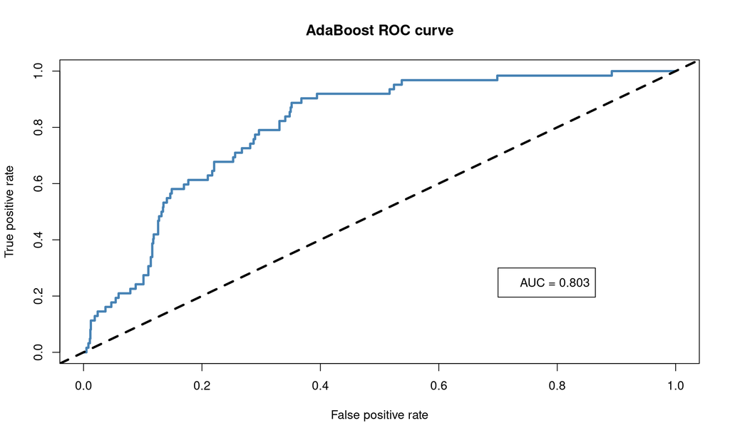

```r
# calculate ROC
perf_pred_adb <- get_roc(fit_adb, df_test)
perf_adb <- perf_pred_adb[[1]]
pred_adb <- perf_pred_adb[[2]]

# take AUC
auc_adb <- round(unlist(slot(performance(pred_adb, measure = "auc"), "y.values")), 3)

# plot
plot(perf_adb, main = "AdaBoost ROC curve", col = "steelblue", lwd = 3)
abline(a = 0, b = 1, lwd = 3, lty = 2, col = 1)
legend(x = 0.7, y = 0.3, legend = paste0("AUC = ", auc_adb))
```

### 3.2.2 TPR, FPR vs Probability cutoff

At which probability cut-off, you’ll get TPR = 1.0?

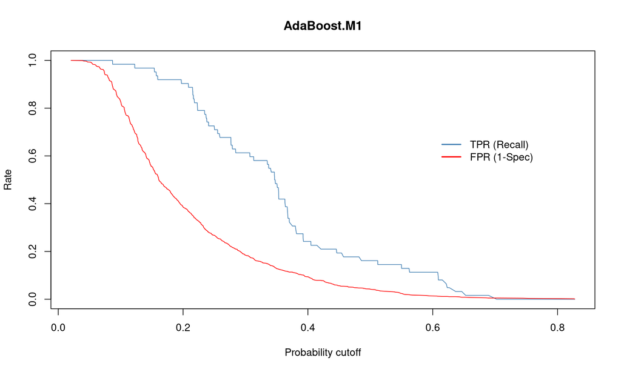

```r
# use pred_rf (pred_roc) object
plot(performance(pred_adb, measure = "tpr", x.measure = "cutoff"),
     col="steelblue",
     ylab = "Rate",
     xlab="Probability cutoff")

plot(performance(pred_adb, measure = "fpr", x.measure = "cutoff"),
     add = T, col = "red")

legend(x = 0.6,y = 0.7, c("TPR (Recall)", "FPR (1-Spec)"),
       lty = 1, col =c('steelblue', 'red'), bty = 'n', cex = 1, lwd = 2)

#abline(v = 0.1, lwd = 2, lty=6)

title("AdaBoost.M1")
```

### 3.2.3 Confusion matrix

```r
pred_prob_adb <- predict(fit_adb, newdata=df_test, type = "prob")

# choose your cut-off
cutoff = 0.12

# turn probabilities into classes
pred_class_adb <- ifelse(pred_prob_adb$yes > cutoff, "yes", "no")

pred_class_adb <- as.factor(pred_class_adb)

cm_adb <- confusionMatrix(data = pred_class_adb,
                reference = df_test$stroke,
                mode="everything",
                positive="yes")

cm_adb
```

```
## Confusion Matrix and Statistics
##
##           Reference
## Prediction  no yes
##        no  345   1
##        yes 870  61
##
##                Accuracy : 0.3179
##                  95% CI : (0.2924, 0.3443)
##     No Information Rate : 0.9514
##     P-Value [Acc > NIR] : 1
##
##                   Kappa : 0.035
##
##  Mcnemar's Test P-Value : <2e-16
##
##             Sensitivity : 0.98387
##             Specificity : 0.28395
##          Pos Pred Value : 0.06552
##          Neg Pred Value : 0.99711
##               Precision : 0.06552
##                  Recall : 0.98387
##                      F1 : 0.12286
##              Prevalence : 0.04855
##          Detection Rate : 0.04777
##    Detection Prevalence : 0.72905
##       Balanced Accuracy : 0.63391
##
##        'Positive' Class : yes
##
```

# 4 Extreme Gradient Boosting: xgbTree

xgbTree has 7 parameters

## 4.1 Training and validation

### 4.1.1 Kappa-optimized

10-fold CV

```r
set.seed(121)

fit_xgb_kp <- train(stroke ~ .,
                 data = df_train_smote,
                 method = "xgbTree",
                 metric = "Kappa",
                 trControl = fit_ctrl_kp10,
                 tuneGrid = expand.grid(
                   .nrounds = 100,
                   .max_depth = seq(3, 15, 1),
                   .eta = 0.3,
                   .gamma = 0.01,
                   .colsample_bytree = 1,
                   .min_child_weight = 1,
                   .subsample = 1
                 ),
                 verbose = FALSE,
                 verbosity = 0)

fit_xgb_kp$bestTune
```

|  | nrounds | max_depth | eta | gamma | colsample_bytree | min_child_weight | subsample |
| --- | --- | --- | --- | --- | --- | --- | --- |
| 9 | 100 | 11 | 0.3 | 0.01 | 1 | 1 | 1 |

## 4.2 Features importance

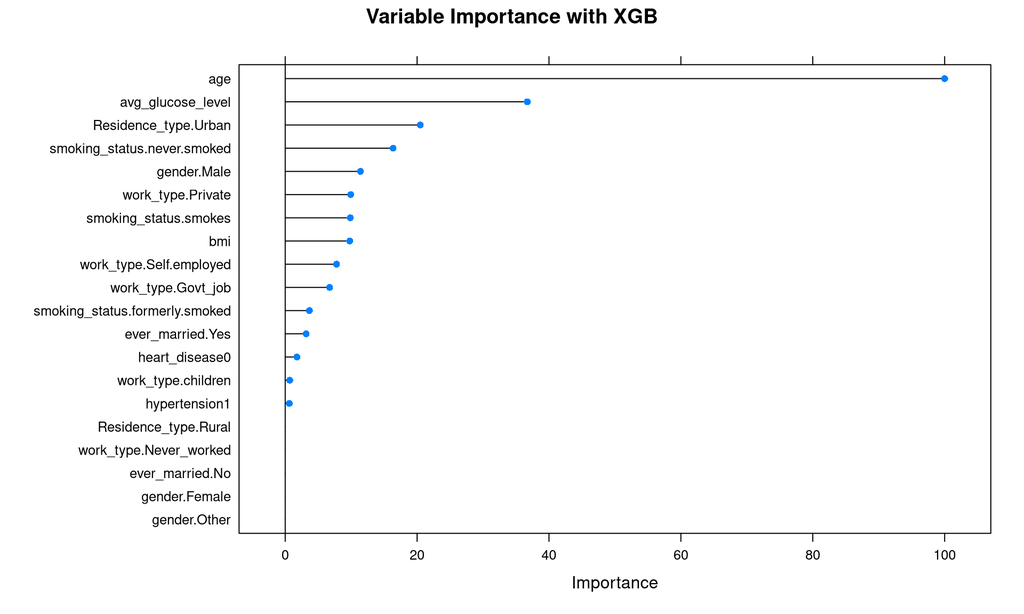

```r
imp_vars_xgb <- varImp(fit_xgb_kp)

plot(imp_vars_xgb, main = "Variable Importance with XGB")
```

## 4.3 Testing

### 4.3.1 ROC curve

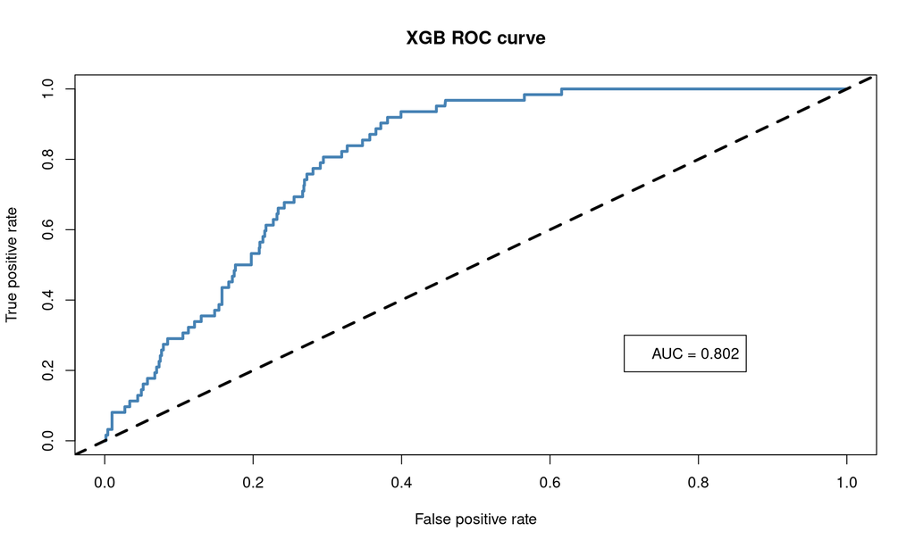

```r
# calculate ROC
perf_pred_xgb <- get_roc(fit_xgb_kp, df_test)
perf_xgb <- perf_pred_xgb[[1]]
pred_xgb <- perf_pred_xgb[[2]]


# take AUC
auc_xgb <- round(unlist(slot(performance(pred_xgb, measure = "auc"), "y.values")), 3)

# plot
plot(perf_xgb, main = "XGB ROC curve", col = "steelblue", lwd = 3)
abline(a = 0, b = 1, lwd = 3, lty = 2, col = 1)
legend(x = 0.7, y = 0.3, legend = paste0("AUC = ", auc_xgb))
```

### 4.3.2 TPR v FPR

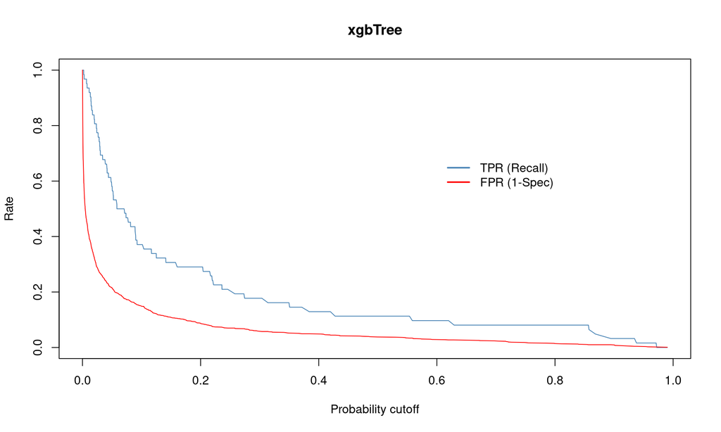

```r
# use pred_xgb object
plot(performance(pred_xgb, measure = "tpr", x.measure = "cutoff"),
     col = "steelblue",
     ylab = "Rate",
     xlab = "Probability cutoff")

plot(performance(pred_xgb, measure = "fpr", x.measure = "cutoff"),
     add = T, col = "red")

legend(x = 0.6,y = 0.7, c("TPR (Recall)", "FPR (1-Spec)"),
       lty = 1, col = c('steelblue', 'red'), bty = 'n', cex = 1, lwd = 2)

#abline(v = 0.1, lwd = 2, lty=6)

title("xgbTree")
```

### 4.3.3 Confusion matrix

```r
pred_prob_xgb <- predict(fit_xgb_kp, newdata=df_test, type = "prob")

# choose your cut-off
cutoff = 0.12

# turn probabilities into classes
pred_class_xgb <- ifelse(pred_prob_xgb$yes > cutoff, "yes", "no")

pred_class_xgb <- as.factor(pred_class_xgb)

cm_xgb <- confusionMatrix(data = pred_class_xgb,
                reference = df_test$stroke,
                mode = "everything",
                positive = "yes")

cm_xgb
```

```
## Confusion Matrix and Statistics
##
##           Reference
## Prediction   no  yes
##        no  1065   41
##        yes  150   21
##
##                Accuracy : 0.8504
##                  95% CI : (0.8297, 0.8696)
##     No Information Rate : 0.9514
##     P-Value [Acc > NIR] : 1
##
##                   Kappa : 0.1174
##
##  Mcnemar's Test P-Value : 5.514e-15
##
##             Sensitivity : 0.33871
##             Specificity : 0.87654
##          Pos Pred Value : 0.12281
##          Neg Pred Value : 0.96293
##               Precision : 0.12281
##                  Recall : 0.33871
##                      F1 : 0.18026
##              Prevalence : 0.04855
##          Detection Rate : 0.01644
##    Detection Prevalence : 0.13391
##       Balanced Accuracy : 0.60763
##
##        'Positive' Class : yes
##
```

# 5 Save the workspace

```r
save.image("data/workspace.RData")
```